# Coding the Level Logic

Godot’s architecture follows a *Composite Tree* design pattern. This means that each component, *Node*, should only manage their direct children.

In our design, the *Level* handles all the interactions between the objects we’ve created until now. It passes relevant cells to the *TowerPlacer*, the *AStarGrid*, and the *Waves* for example.

Remove any testing lines you might have. It’s time to start the implementation of the actual *Level* behavior.

## Setting up the TileMap’s metadata

We start by setting up the *TowerPlacer* and the *AStarGrid* in the *Level* script. We feed them with the tiles we’ve drawn with the *TileMap*.

We need two constants to represent the ID of the tiles that represent each “metadata”. This is so that we can use them with *TileMap*’s `get_used_cells_by_id()` method. Like what we’ve done in our latest test.

We feed `TOWER_PLACEABLE_CELLS_ID` to the *TowerPlacer*. Its default value should be `3`, but as mentioned in our path finding test, this may differ for you.

Rename the `WALKABLE_CELLS_ID` to `ENEMY_WALK_PATH_CELLS_ID`. This makes more sense in this context.

As the *Level* feeds the *TowerPlacer* with cells, let’s delete the *Towers* we’ve added as children of the *TowerPlacer*.

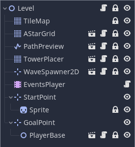

Back to the *Level* script, create a reference to the *TowerPlacer*. This one is going to be a public reference because we need to access it when we implement the tower purchasing interface.

```
# Controls Wave's flow and TowerPlacement
extends Node2D

const TOWER_PLACEABLE_CELLS_ID := 3
const ENEMY_WALK_PATH_CELLS_ID := 2

onready var tower_placer := $TowerPlacer

onready var _path_preview := $PathPreview
onready var _astar_grid := $AStarGrid
onready var _tilemap := $TileMap
onready var _start_point := $StartPoint
onready var _goal_point := $GoalPoint
```

We have everything in place to set up the level’s metadata. Let’s create the `_setup()` method.

We pass all the cells that match the `TOWER_PLACEABLE_CELLS_ID` to the `tower_placer.setup_available_cells()` method. We can use the `_tilemap.get_used_cells_by_id()` method.

Let’s take a look at `_astar_grid`. We set its `walkable_cells` property to be the cells that match the `ENEMY_WALK_PATH_CELLS_ID`.

Let’s setup the `_astar.start_point` and `goal_point` as well by passing the position of the *Level*’s `_start_point` and `_goal_point`.

Now we can draw the walking path using the `_path_preview` by creating a method called `show_walkable_path()`.

```
func _setup() -> void:
    tower_placer.setup_available_cells(_tilemap.get_used_cells_by_id(TOWER_PLACEABLE_CELLS_ID))

    _astar_grid.walkable_cells = _tilemap.get_used_cells_by_id(ENEMY_WALK_PATH_CELLS_ID)
    _astar_grid.start_point = _start_point.position
    _astar_grid.goal_point = _goal_point.position

    show_walkable_path()
```

This method receives a `walking_path` parameter which is `_astar_grid.get_walkable_path()` by default.

Inside this method, we erase the current path before setting the `_path_preview.points` to be the `walking_path`.

As the *PathPreview* is a node designed to provide visual feedback to players, it has some fancy methods to draw the path. One of them is the `fade_in()` method which we call when we’re ready.

```
func show_walkable_path(walking_path := _astar_grid.get_walkable_path()) -> void:
    _path_preview.clear_points()
    _path_preview.points = walking_path
    _path_preview.fade_in()
```

Let’s call the `_setup()` method in the `_ready()` callback and check how the code looks at the moment.

`Level.gd`

```
extends Node2D

const TOWER_PLACEABLE_CELLS_ID := 3
const ENEMY_WALK_PATH_CELLS_ID := 2

onready var tower_placer := $TowerPlacer

onready var _path_preview := $PathPreview
onready var _astar_grid := $AStarGrid
onready var _tilemap := $TileMap
onready var _start_point := $StartPoint
onready var _goal_point := $GoalPoint


func _ready() -> void:
    _setup()


func show_walkable_path(walking_path := _astar_grid.get_walkable_path()) -> void:
    _path_preview.clear_points()
    _path_preview.points = walking_path
    _path_preview.fade_in()


func _setup() -> void:
    tower_placer.setup_available_cells(_tilemap.get_used_cells_by_id(TOWER_PLACEABLE_CELLS_ID))

    _astar_grid.walkable_cells = _tilemap.get_used_cells_by_id(ENEMY_WALK_PATH_CELLS_ID)
    _astar_grid.start_point = _start_point.position
    _astar_grid.goal_point = _goal_point.position

    show_walkable_path()
```

Now, let’s test if the *TowerPlacer* is working. Add a line passing an instance of a *Tower* to its `add_new_tower()` method after we’ve set it up.

```
func _ready() -> void:
    _setup()

    # This is a testing line, delete it after testing the *TowerPlacer*
    tower_placer.add_new_tower(load("res://Objects/Towers/Tower.tscn").instance())
```

With that, we can see that the *TowerPlacer* doesn’t allow us to place *Towers* on the tiles other than free ones.

[figure not shown]

## Spawning waves

The *Waves* we create don’t have access to terrain information. The *Level* has to provide them their `movement_path` using the `_astar.get_walkable_path()`.

Every time the *WaveSpawner2d* creates a new *Wave*, we feed it with its `movement_path`.

Let’s start by adding a reference to the *WaveSpawner2D*.

```
onready var _wave_spawner := $WaveSpawner2D
```

Now, let’s create a method to spawn and setup a new wave. The *EventsPlayer* is going to use this method to create new events. We name it `spawn_wave()` because it’s a public method.

In this method, we tell the `_wave_spawner` to spawn a new *Wave*. We store a reference of the *Wave* it creates in a local variable called `wave`.

Then, we can connect the `wave`’s `finished` signal to a callback so we know when the enemies have died or reached their goal. This is important so we can finish the current round. But for now, let’s keep this callback empty.

```
func spawn_wave() -> void:
    var wave = _wave_spawner.spawn()
    wave.connect("finished", self, "_on_Wave_finished")


func _on_Wave_finished() -> void:
    pass
```

Back to the `spawn_wave()` method, we need to setup the `wave` path. We create a private method to isolate any issues if they happen to appear. We can call this method `_setup_wave_path()` and it receives a *Wave* as argument.

We call the `set_movement_path()` method on the `wave`. This method asks for a *PoolVector2Array* which will come from the `_astar_grid.get_walkable_path()` method. The *Curve2D* we’ve been designing manually in our *Waves* will now match the path found by the *AStarGrid*.

```
func _setup_wave_path(wave: Wave) -> void:
    wave.set_movement_path(_astar_grid.get_walkable_path())
```

In the `spawn_wave()` method, we can call the `_setup_wave_path()` and pass the `wave` as argument. After this, the wave is ready to start.

```
func spawn_wave() -> void:
    var wave = _wave_spawner.spawn()
    wave.connect("finished", self, "_on_Wave_finished")
    _setup_wave_path(wave)

    wave.start()
```

To test our wave spawning behavior, we call the `spawn_wave()` below the `_setup()` call in the `_ready()` callback. Then, let’s test the scene.

`Level.gd`

```
func _ready() -> void:
    _setup()

    # This is a testing line, remove it after testing
    spawn_wave()
```

[figure not shown]

## Starting and Finishing

The *Level* doesn’t start until the player finishes placing towers strategically and the *Level* will stay still until it receives a call to start. To maintain the game’s flow, we also need to know when the *Level* finished so we can end the game or move on to the next level.

Let’s create a `started` and a `finished` signal. To implement the starting procedures, create a `start()` method.

In the `start()` method, we fade out the *PathPreview* because highlighting the walking path is not useful after the planning phase.

Then, we tell the *EventsPlayer* to play the next event. We create a reference to the *EventsPlayer* in the *Level* script using an `onready` variable. Then in the `start()` method, call `_events_player.play_current_event()` before emitting the `started` signal.

```
signal started
signal finished

onready var _events_player := $EventsPlayer


func start() -> void:
    _path_preview.fade_out()
    _events_player.play_current_event()
    emit_signal("started")
```

Here’s where our *EventsPlayer* shines. Recall that we created two animations which changed the *Wave Scene* the *WaveSpawner2d* spawns. But we can use animations to create any sort of in-game event. For instance, if we had a *Wave* with a boss, we could use a *CanvasModulate* to tint the screen in red, or even do some camera shake as the boss moves.

But for now, let’s add a *Call Function Track* to our animations. We call the *Level*’s `spawn_wave()` method right at the beginning of each animation.

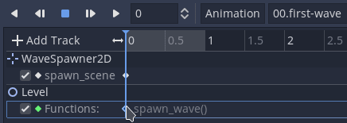

Let’s move on to the level finishing logic. Create a method and name it `finish()`. We should only consider the level finished if the player was capable of keeping their base alive.

We create a reference for the *PlayerBase* using an `onready` variable and check if its `health` property is above `0` in the `finish()` method. If that’s the case, we emit the `finished` signal.

```
onready var _player_base := $GoalPoint/PlayerBase

func finish() -> void:
    if _player_base.health > 0:
        emit_signal("finished")
```

But our level finishes after it goes through all its events which we verify at the end of each round.

A round finishes when there are no enemies left on the current wave. We’ve connected the *Wave*’s `finished` signal to the *Level*’s `_on_Wave_finished()` callback. This is where we tell the level to start the round.

```
func _on_Wave_finished() -> void:
    start_round()
```

Inside the `start_round()` method, we can do two things. Either we reach the end of the *Level* and call the `finish()` method because there isn’t anything left to do, or we emit the signal telling the current round has finished and a new one should start. Then the game enters in the plan mode again and the level waits for something to call its `start()` again.

To know if we’ve gone through all events we’ve designed, we can check if the `_events_player.current_event` is equal to or beyond the amount of animations. If the `current_event` value iterates to the point where it reaches the amount of animations, the player has finished the *Level*.

```
func start_round() -> void:
    if _events_player.current_event >= _events_player.get_animation_list().size():
        finish()

        # Returns from the function to prevent emitting the `round_finished`
        # signal, which would lead to the plan mode
        return
    emit_signal("round_finished")
```

## Code so far

We went through a lot in this lesson, so let’s take a look at our final *Level* script.

`Level.gd`

```
extends Node2D

signal round_finished
signal started
signal finished


const TOWER_PLACEABLE_CELLS_ID := 3
const ENEMY_WALK_PATH_CELLS_ID := 2

onready var tower_placer := $TowerPlacer

onready var _path_preview := $PathPreview
onready var _astar_grid := $AStarGrid
onready var _tilemap := $TileMap
onready var _start_point := $StartPoint
onready var _goal_point := $GoalPoint
onready var _wave_spawner := $WaveSpawner2D
onready var _events_player := $EventsPlayer
onready var _player_base := $GoalPoint/PlayerBase


func _ready() -> void:
    _setup()


func start() -> void:
    _path_preview.fade_out()
    _events_player.play_current_event()
    emit_signal("started")


func finish() -> void:
    if _player_base.health > 0:
        emit_signal("finished")


func spawn_wave() -> void:
    var wave = _wave_spawner.spawn()
    wave.connect("finished", self, "_on_Wave_finished")
    _setup_wave_path(wave)

    wave.start()

func show_walkable_path(walking_path := _astar_grid.get_walkable_path()) -> void:
    _path_preview.clear_points()
    _path_preview.points = walking_path
    _path_preview.fade_in()


func start_round() -> void:
    if _events_player.current_event >= _events_player.get_animation_list().size():
        finish()
        return
    emit_signal("round_finished")


func _setup() -> void:
    tower_placer.setup_available_cells(_tilemap.get_used_cells_by_id(TOWER_PLACEABLE_CELLS_ID))

    _astar_grid.walkable_cells = _tilemap.get_used_cells_by_id(ENEMY_WALK_PATH_CELLS_ID)
    _astar_grid.start_point = _start_point.position
    _astar_grid.goal_point = _goal_point.position

    show_walkable_path()


func _setup_wave_path(wave: Wave) -> void:
    wave.set_movement_path(_astar_grid.get_walkable_path())


func _on_Wave_finished() -> void:
    start_round()
```

## Testing the level

Now we should have a functioning *Level*. Let’s make some tests to see if it behaves as it should. Our *Level* controls the *Waves* flow and the environment metadata.

To test this, we can make a map with some *Non Placeable Cell* tiles. Use the *TileMap* to draw some cells. Select the *Non Placeable Cell* tile and toggle on the *Enable Priority* flag to get some variants of this tile.

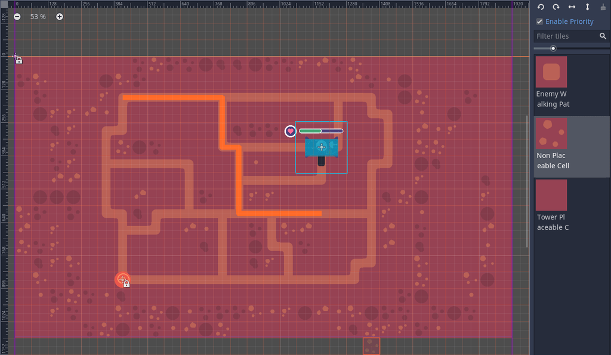

For testing purposes, let’s connect the *Level*’s `round_finished` to itself.

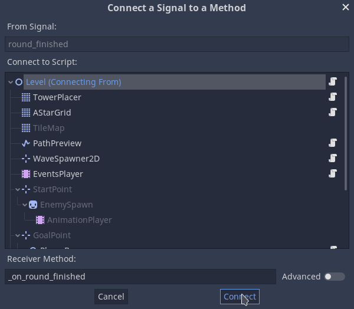

We call the `start()` method to simulate the game’s flow.

```
# This is a testing block, delete it after testing
func _on_round_finished() -> void:
    start()
# End of testing block
```

[figure not shown]

To simulate the plan mode, let’s yield for the `tower_placer`’s `tower_placed` signal. Then we can call the `start()` method.

```
func _ready() -> void:
    _setup()

    # This is a testing block, delete it after testing
    tower_placer.add_new_tower(load("res://Objects/Towers/Tower.tscn").instance())
    yield(tower_placer, "tower_placed")
    start()
    # End of testing block
```

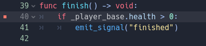

To prevent the *PlayerBase* from exploding with a single hit, let’s bulk up its *Health* to `20`. We can use the *Inspector* for that.

Now, hit the *Play Scene* button!

With that, as soon as the second wave finishes, Godot should prompt the *Debugger* tab. It will look like this:

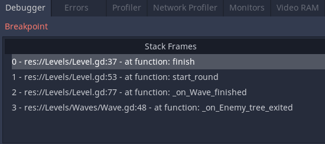

Through the *Stack Frames*, we can see that the *Wave* finishes and triggers the `_on_Wave_finished()` callback. This, in turn, calls the `start_round()` method. As there aren’t any events left, it calls the `finish()` method and we reach the breakpoint. Our *Level* works as expected!

Don’t forget to clean up the script and disconnect the *Level*’s `round_finished` signal.